# FigureYa122mut2expr

小丫画图出品

2019-7-29

欢迎关注“小丫画图”公众号，同名知识星球等你加入

小丫微信: epigenomics E-mail: figureya@126.com

作者：赵龙，中科院遗传所在读博士

擅长：ChIP-seq，MNase-seq，ATAC-seq，HiC，ChIA-PET，GWAS分析，R语言。

兴趣：单细胞RNA-seq，ATAC-seq，机器学习相关。

小丫编辑校验

## 需求描述

虽然原文附件给出了代码，但自己看着费劲，请高手带我们理解并复现原文的Figure 1b建模。

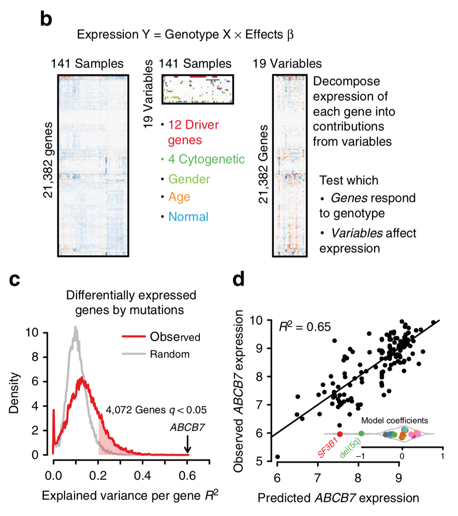

出自http://www.nature.com/articles/ncomms6901

代码在原文补充材料中有提供，里面有很多东西值得学习。同时我自己写了一些比原文精简的代码（一些数据命名尽量和原文一致，确保小伙伴跑的时候能够理解不同做法的异曲同工）。

**小丫碎碎念：**像这种附带代码的好文章越来越多，是非常好的学习资源。

这类文章怎么找到呢？小丫的经验是：在感兴趣的期刊主页的高级搜索里，搜code或script，同时限定research article和发表年份等信息。检索结果里会有上下文，一眼扫过去，就能看到哪些文章带代码。

怎样学习这类代码？这次众筹就从这篇带代码的文章带你上手，以后你就可以自己去挖宝藏了。推荐路线：

- 先尝试自己写，或者至少在脑子里猜测作者是用什么方法哪个包实现的
- 看原文代码，边看边实践
- 记笔记，思考这段代码能应用到哪些场景上，可以尝试按照FigureYa的格式来写，或者干脆写成R包（Y叔说写R包要趁早）
- 用在自己的数据上，争取能用到paper里，经历了这一过程，你会有质的提升

自己死磕一篇文章的代码是孤独的，遇到问题也没人讨论，以后有机会我们可以搞个学习小组，感兴趣的小伙伴一起讨论同一篇文章的代码。

## 应用场景

已有genotype和转录数据，通过线性模型解析突变对基因表达的贡献，即基因表达如何响应不同的genotype，不同的突变如何影响基因表达。

该模型的假设：

1. 每个突变位点只是影响特定的一些基因的表达；
2. 包含2种以上突变的个体，基因表达变化为两个或多个突变影响基因集合的并集；

缺点：该模型忽略了基因间的相互调控。

如果想要系统的研究基因之间的相互关系，就需要更多的基因样本容量，所以该线性模型方法是相对小样本量的很好的方式。

## 环境设置

使用国内镜像安装包

```r
options("repos"= c(CRAN="https://mirrors.tuna.tsinghua.edu.cn/CRAN/"))
options(BioC_mirror="http://mirrors.ustc.edu.cn/bioc/")
BiocManager::install("hgu133plus2.db")
```

加载包

```r
library(openxlsx)
library(affy) #芯片数据处理
library(gcrma) #芯片数据处理
library(org.Hs.eg.db) #人类基因注释
library(hgu133plus2.db) #人类基因注释
library(limma) #线性模型
library(RColorBrewer) #颜色

Sys.setenv(LANGUAGE = "en") #显示英文报错信息
options(stringsAsFactors = FALSE) #禁止chr转成factor
```

## 输入数据的预处理

需要两种输入数据：表达数据和基因型数据

表达数据：159个突变体和17个正常个体芯片数据，下载地址：< http://www.ncbi.nlm.nih.gov/geo/query/acc.cgi?acc=GSE58831>，点击Download里的http下载（早上下载速度更快），解压缩到当前文件夹。

genotype和表型数据：Supplementary Data 1—ncomms6901-s2.xlsx，其中部分个体数据缺失。

### 芯片数据处理：

以下是芯片数据处理过程，主要用到affy，gcrma包

下面这一步需要较长的运行时间，我把运行结果gset保存在文件里，便于再次运行时读取

```r
celFiles <- dir("GSE58831_RAW",full.names=T)  #读取文件夹下面文件
affyBatch <- read.affybatch(filenames = celFiles)  #Read CEL files into an Affybatch
gset <- gcrma(affyBatch)  #converts an AffyBatch into an ExpressionSet
save(gset, file = "gset.RData")
```

```r
#读入gset
load("gset.RData")

#把sample名字GSM1420467_MDS194.CEL.gz模式替换成GSM1420467
samples <- sub("_.+","", sampleNames(gset))
sampleNames(gset) <- samples

#替换探针id替换成ENTREZID，这里需要用到hgu133plus2.db。但是存在多对一的情况，例如1570001_at，222201_s_at两个探针都对应9994这个ENTREZID，所以需要把两个探针数据取平均值：
e <- exprs(gset)  #calculate expression
e[1:3,1:3] #探侦组的表达矩阵
```

```
##           GSM1420393 GSM1420394 GSM1420395
## 1007_s_at   4.440616   4.308647   4.308647
## 1053_at     8.905845   9.073703   9.600805
## 117_at      2.739938   3.449308   2.734385
```

```r
tab <- select(hgu133plus2.db, keys = keys(hgu133plus2.db), columns = c("ENTREZID"))   #build a data with tow columns,1,probe id 2,ENTREZID
```

上面的e里面保存了探针组的表达矩阵，需要转换成ENTREZID对应的表达矩阵，这里提供三种方式，便于理解：

**方式一：**我自己用的code，比较繁琐，也容易理解。

思路是：在表达数据中加入ENTREZID，然后根据ENTREZID把dataframe通过split转换成list。之后把list中第一列的PROBEID和最后一列的ENTREZID去掉，最后通过sapply得到表达数据：

```r
expr <- as.data.frame(e)
expr$PROBEID <- rownames(expr)
expr.id <- merge(expr,tab,by="PROBEID")
list <- split(expr.id, expr.id[,178])
list_new <- list
for (i in 1:length(list_new)){
list_new[[i]] <- list[[i]][,2:177]
}
geneExpr <- t(sapply(list_new,colMeans))
```

**方式二：**这是文章作者的代码，明显简洁许多，运行速度也快了很多，主要是在转换list这里节省了大量时间。

作者的思路是：首先把只含有PROBEID和ENTREZID两列数据按照ENTREZID转换成list，然后通过sapply加一个function就可以了:

```r
geneExpr <- t(sapply(split(tab[,1], tab[,2]), function(ids){
                    colMeans(e[ids,,drop=FALSE])
                }))
```

**方式三：**如果以上理解有点困难，可以通过以下代码进行逐步操作，就会明白了：

```r
list <- split(tab[,1], tab[,2])
colmean <- function(ids){
 colMeans(e[ids,,drop=FALSE])
 }

geneExpr1 <- sapply(list,colmean)
geneExpr <- t(geneExpr1)
```

这里有一个小tip就是`e[ids,,drop=FALSE]`，一般来讲用中括号[]来提取大于一列时，得到的是matrix，但是提取某一列的时候一般得到的数据是vector，如果加上drop=FALSE参数，即使提取一列，同样也会得到matrix。

### genotype突变信息

```r
mdsData <- read.xlsx("ncomms6901-s2.xlsx", startRow = 2, check.names = F) #从第2行开始读入
head(mdsData)
```

```
##      PDID      GEOID                  File
## 1 PD6175a GSM1420393 GSM1420393_MDS009.CEL
## 2 PD6173a GSM1420394 GSM1420394_MDS011.CEL
## 3 PD6185a GSM1420395 GSM1420395_MDS012.CEL
## 4 PD6184a GSM1420396 GSM1420396_MDS014.CEL
## 5 PD6183a GSM1420397 GSM1420397_MDS015.CEL
## 6 PD6198a GSM1420398 GSM1420398_MDS025.CEL
##   Described.in.Papaemmanuil.et.al,.Blood.2013
## 1                                         yes
## 2                                         yes
## 3                                         yes
## 4                                         yes
## 5                                         yes
## 6                                         yes
##   Described.in.Pellagatti.et.al,.Leukemia.2010 Type Gender Age
```

[output cut: 83 more lines]

```r
nu <- which(is.na(mdsData$PDID)) #mdsData中PDID为NA的行名
design <- mdsData[-nu,c(27:79,7,90)] #把mdsData中PDID为NA的行去掉（其中包括了normal的行）
design[1:3,1:3]
```

```
##   SF3B1 TET2 SRSF2
## 1     0    0     0
## 2     0    0     0
## 3     0    0     0
```

把normal信息整合成起来，normal信息的所有突变基因列为0。定义年龄数据为NA：

```r
normal <- mdsData[mdsData[,6]=="Normal",c(27:79,7,90)]
normal[is.na(normal)] <- 0
normal$age_imp <- NA

# 把突变体信息和野生型信息rbind到一起。根据7503基因表达定义性别，如果该基因表达大于5，则认为是男性选取突变基因：选取标准是至少有5个个体含有这个突变。（如果小于5的rare突变，该模型表现不会很好）
design <- rbind(design,normal)
design[125:141,"Gender"] <- geneExpr["7503",as.character(mdsData[mdsData[,6]=="Normal",2])] > 5
design = design[,colSums(design,na.rm=T)>=5]
design$Normal <- c(rep(0,nrow(design)-nrow(normal)),rep(1,nrow(normal)))
 design$offset <- 1
design <- design[,c(20,1:16,19,17:18)]
design$age_imp <- scale(design$age_imp,center=T,scale=F)
rownames(design) <- c(as.character(mdsData[-nu,2]), as.character(mdsData[mdsData[,6]=="Normal",2]))

#把design中NA替换成平均值,这个在日常数据处理过程中会经常用到
for(j in 1:ncol(design))
    design[is.na(design[,j]),j] <- mean(design[,j], na.rm=TRUE)
head(design)
```

```
##            offset SF3B1 TET2 SRSF2 ASXL1 DNMT3A RUNX1 U2AF1 TP53 EZH2
## GSM1420393      1     0    0     0     0      0     0     0    0    0
## GSM1420394      1     0    0     0     0      0     0     1    0    0
## GSM1420395      1     0    0     0     0      0     0     0    0    0
## GSM1420396      1     0    0     0     0      0     0     0    0    0
## GSM1420397      1     0    0     0     1      0     0     0    0    0
## GSM1420398      1     0    0     0     0      0     0     0    0    0
##            STAG2 ZRSR2 JAK2 del(5q) tri(8) del(12p) del(20q) Normal Gender
## GSM1420393     0     0    0       1      0        0        0      0      1
## GSM1420394     0     0    0       1      0        0        0      0      1
## GSM1420395     0     0    0       1      0        0        0      0      1
## GSM1420396     0     0    1       1      0        0        0      0      1
## GSM1420397     0     0    0       1      0        0        0      0      1
## GSM1420398     0     0    0       0      0        0        0      0      0
##              age_imp
## GSM1420393  10.58871
## GSM1420394  -4.41129
## GSM1420395 -15.41129
## GSM1420396 -23.41129
## GSM1420397 -14.41129
## GSM1420398  -4.41129
```

## 构建线性模型

这里主要用到limma包，其中F.stat，是F-statistic检验，该值越大，一般p值越小，即差异显著。

```r
glm <- lmFit(geneExpr[,rownames(design)], design = design )
glm <- eBayes(glm)

F.stat <- classifyTestsF(glm[,-1],fstat.only=TRUE)
```

## 开始画图-b

b图里有三个小图，我们分别来画。

定义颜色，主要定义19种颜色，每种颜色在之后会代表每一个design的列信息：

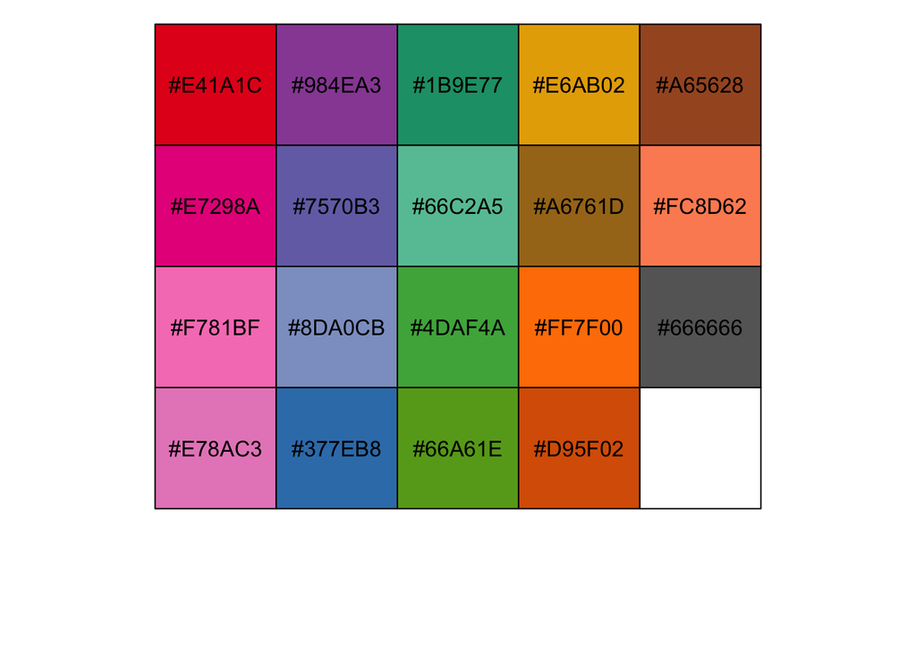

```r
colMutations = c(brewer.pal(8,"Set1")[-6], rev(brewer.pal(8,"Dark2")), brewer.pal(7,"Set2"))[c(1:12,16:19,13:15)]
o <- order(apply(col2rgb(colMutations),2,rgb2hsv)[1,])
colMutations <- colMutations[rev(o)][(4*1:19 +15) %% 19 + 1]
names(colMutations) <- colnames(design)[-1]

library("scales")
show_col(colMutations)
```

选取Fstat最大的前1000个基因用于作图

```r
w <- names(sort(F.stat, decreasing = TRUE)[1:1000])
z <- design[,-1]
geneExpr <- geneExpr[,rownames(design)]
```

### b中间图：

这是另外一种画heatmap的方法，也是最让我惊艳的一部分。

大体思路就是：首先通过hclust对数据进行聚类，之后通过rasterImage按照聚类的顺序画heatmap。

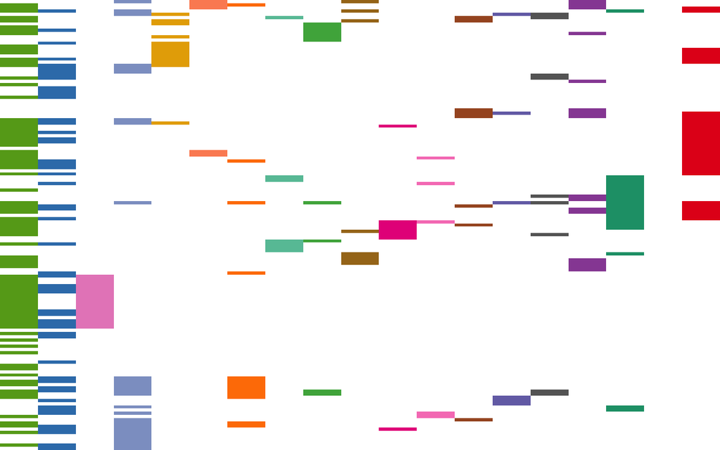

```r
par(bty="n", mgp = c(2,.33,0), mar=rep(0,4), las=1, tcl=-.25, xpd=NA)
plot(NA,NA, xlim=c(0,ncol(design)), ylim=c(0,nrow(design)), xaxt="n", yaxt="n", xlab="",ylab="", xaxs="i", yaxs="i")
h <- hclust(dist(z[,1:16]))
j <- hclust(dist(t(z)))

rasterImage(sapply(1:ncol(z), function(i) ifelse(z[,i]>0, colMutations[i-1], "#FFFFFF"))[h$order,j$order], 0, 0, ncol(design), nrow(design), interpolate=FALSE)
```

可以把画图部分分解来做:

```r
func <- function(i) ifelse(z[,i]>0, colMutations[i-1], "#FFFFFF")
matrix <-sapply(1:ncol(z), func)
matrix_order <- matrix[h$order,j$order]
rasterImage(matrix_order, 0, 0, ncol(design), nrow(design), interpolate=FALSE)
```

### b左侧图：

首先是把基因表达的大小分成12份，然后换成11个颜色，之后组成颜色的矩阵。通过rasterImage画出来。rasterImage还有其他有意思的用法，可以参考Y叔的https://guangchuangyu.github.io/cn/2017/04/ggimage/

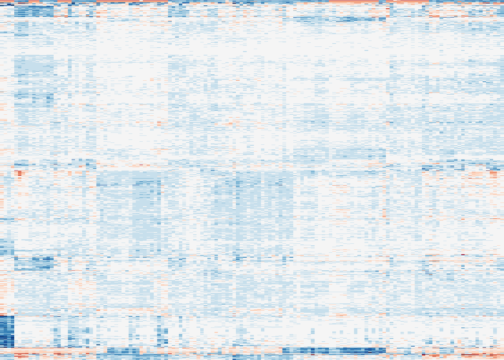

```r
par(bty="n", mgp = c(2,.33,0), mar=rep(0,4), las=1, tcl=-.25, xpd=NA)
z <- geneExpr[w,]-rowMeans(geneExpr[w,])
h <- hclust(dist(z))
i <- hclust(dist(t(z)))
plot(NA,NA, xlim=c(0,ncol(geneExpr)), ylim=c(0,1000), xaxt="n", yaxt="n", xlab="",ylab="", xaxs="i", yaxs="i")
rasterImage(matrix(brewer.pal(11,"RdBu")[cut(z[h$order,i$order], 12)], ncol=ncol(geneExpr)), 0,0,ncol(geneExpr),1000, interpolate=FALSE)
```

### b右侧图：

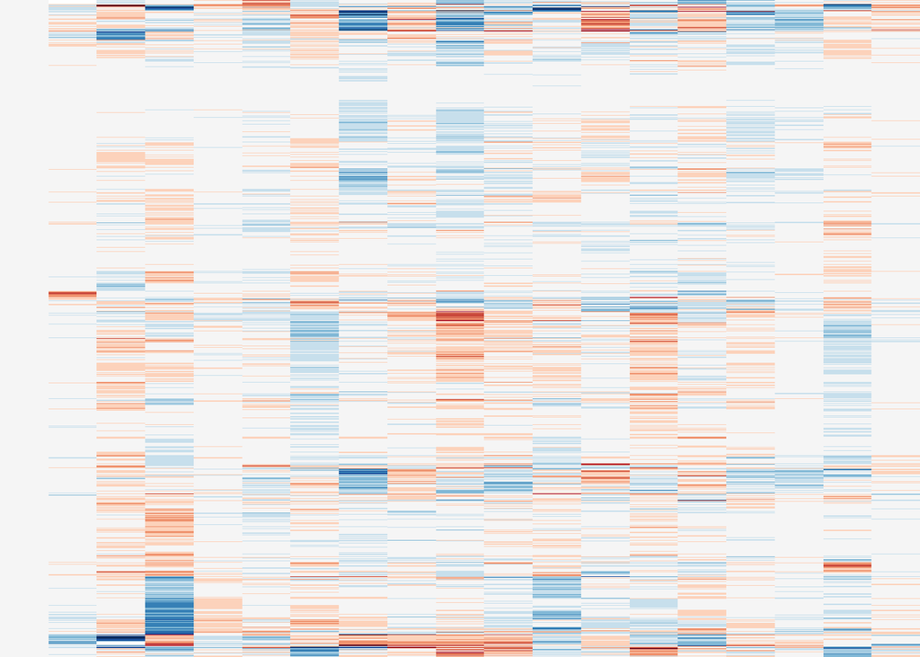

```r
par(bty="n", mgp = c(2,.33,0), mar=rep(0,4), las=1, tcl=-.25, xpd=NA)
plot(NA,NA, xlim=c(0,ncol(design)-1), ylim=c(0,1000), xaxt="n", yaxt="n", xlab="",ylab="", xaxs="i", yaxs="i")
rasterImage(matrix(brewer.pal(11,"RdBu")[cut(glm$coefficients[w,-1][h$order,j$order], seq(-3,3,l=12))], ncol=ncol(design)-1), 0,0,ncol(design)-1,1000, interpolate=FALSE)
```

## c和d

仅用b图的heatmap回答基因表达如何响应不同的genotype以及各种不同的突变如何影响基因表达还不够完美，作者又画了c和d图。

原文代码用baseplot画c和d图，我自己用ggplot2复现了c和d图。

```r
set1 = c(brewer.pal(9,"Set1"),brewer.pal(8, "Dark2"))
source("mg14.R") #From https://github.com/mg14/mg14
```

### 1. 构建随机的表型数据。

```r
F.stat <- classifyTestsF(glm[,2:17],fstat.only=TRUE)
set.seed(42)
rlm <- lmFit(geneExpr[,rownames(design)], apply(design, 2, sample))
rlm <- eBayes(rlm)
R.stat <- classifyTestsF(rlm[,2:17],fstat.only=T)
```

### 2. 计算基因型差异和表达差异之间的R平方。

实话实说作者的计算公式没太理解。一般来讲计算R平方R2=SSR/SST=1-SSE/SST，其中：SST=SSR+SSE，SST(total sum of squares)为总平方和，SSR(regression sum of squares)为回归平方和，SSE(error sum of squares) 为残差平方和。这里的代码是：

```r
Rgenetics = 1 - 1/(1 + F.stat * 15/(nrow(design)-ncol(design)))
Pgenetics = 1 - 1/(1 + R.stat * 15/(nrow(design)-ncol(design)))
names(Rgenetics) <- names(Pgenetics) <- rownames(geneExpr)
```

Rgenetics正式基因型数据；Pgenetics随机基因型数据。

### 3. 寻找adjust.p值小于0.05的基因（相关性最强的基因）

```r
df1 <- attr(F.stat,"df1")
df2 <- attr(F.stat,"df2")
F.p.value <- pchisq(df1*F.stat,df1,lower.tail=FALSE)

r <- min(Rgenetics[p.adjust(F.p.value,"BH")<0.05])
```

前三步为计算p值。r：adjust.p <0.05的最小的Rgenetics(相关系数)的值.我们认为Rgenetics大于r的基因都是和突变有相关性的基因。

### 4. 原文画c图的代码

```r
par(bty="n", mgp = c(2,.33,0), mar=c(3,2.5,1,1)+.1, las=1, tcl=-.25, xpd=NA)
#计算Pgenetics的density
d <- density(Pgenetics,bw=1e-3)
#这里的f代表缩放的尺度，原文是说由nrow(gexpr)/512得到的。
f <- 1
plot(d$x, d$y * f, col='grey', xlab=expression(paste("Explained variance per gene ", R^2)), main="", lwd=2, type="l", ylab="", xlim=c(0,0.7))
title(ylab="Density", line=1.5)
#计算Rgenetics的density
d <- density(Rgenetics, bw=1e-3)
#找出Rgenetics大于r的基因
x0 <- which(d$x>r)
#画fill的密度曲线
polygon(d$x[c(x0[1],x0)], c(0,d$y[x0])* f, col=paste(set1[1],"44",sep=""), border=NA)
lines(d$x, d$y* f, col=set1[1], lwd=2)
#添加文字。这里和原文差了~20个基因，也没太深究原因
text(d$x[x0[1]], d$y[x0[1]]*f, pos=4, paste(sum(Rgenetics > r), "genes q < 0.05"))
arrows(Rgenetics["22"], par("usr")[4]/7, Rgenetics["22"], par("usr")[4]/50, length=0.05)
#找出相关性最强的基因。
M_Rgenetics <- sort(Rgenetics,decreasing=T)
head(M_Rgenetics)
```

```
##        22     11138      9897     23168     79632     22925
## 0.5863562 0.5550277 0.5175865 0.5174996 0.5038118 0.4913283
```

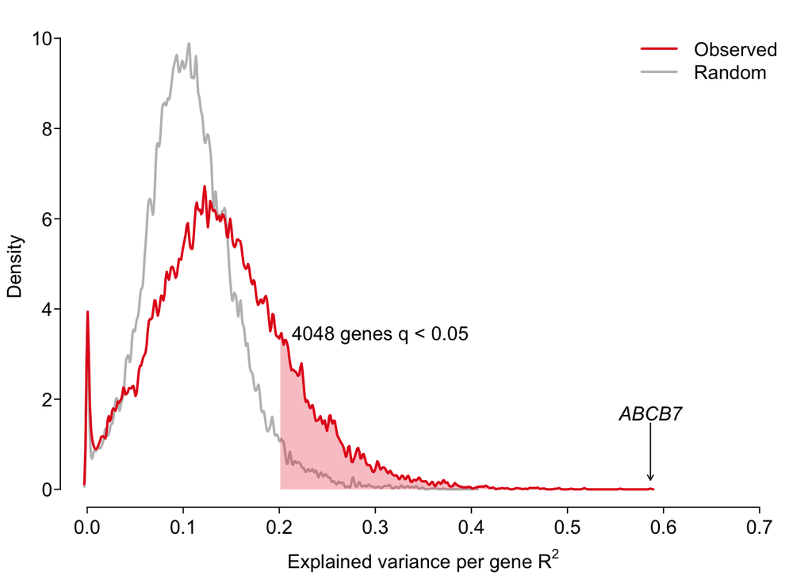

```r
#这里ENTREZID ID 22就是ABCB7，相关性0.5863562（不是本专业，对生物学问题完全无感）
text(Rgenetics["22"], par("usr")[4]/8, "ABCB7", font=3, pos=3)
legend("topright", bty="n", col=c(set1[1], "grey"), lty=1, c("Observed","Random"), lwd=2)
```

### 5. 原文画d图的代码

首先通过上面得到的线性模型预测一下基因表达水平。首先是预测所有的基因和突变的关系。这里涉及到一个“%*%”，这个代表矩阵相乘的含义。矩阵相乘是第一个矩阵的row* 第二个矩阵column的和。

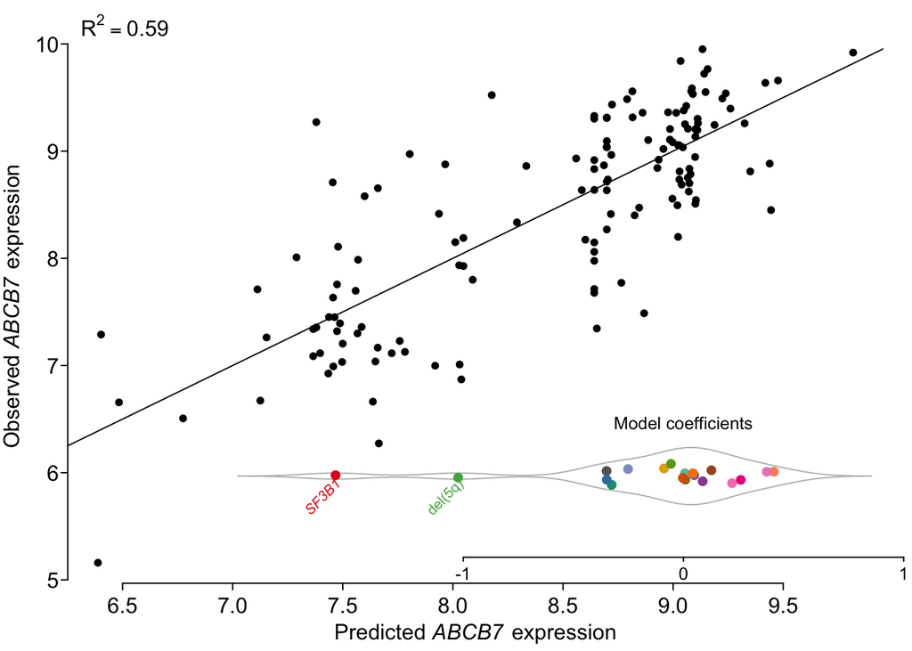

```r
glmPrediction <- glm$coefficients %*% t(design)

par(bty="n", mgp = c(1.5,.33,0), mar=c(2.5,2.5,1,1)+.1, las=1, tcl=-.25)
#首先画一个散点，这个是ABCB7这个基因，横坐标代表预测的基因表达值，纵坐标代表真实的值，因为有141个样本突变信息和表达数据能够对应，所以一共有141个点。
plot(glmPrediction["22",], geneExpr["22",rownames(design)], ylab=expression(paste("Observed ",italic("ABCB7"), " expression")), xlab=expression(paste("Predicted ",italic("ABCB7"), " expression")), pch=16, cex=.8)
abline(0,1)
#在右下方添加小图，首先定义出小图的位置，通过par("usr")得到大图的位置，然后计算小图的位置，x0，y0分别代表小图的横纵坐标x，y轴在大图中的位置
y <- glm$coefficients["22",-1]+glm$coefficients["22",1]
u <- par("usr")
par(xpd=NA)
x0 <- rep(u[3]+1,ncol(design)-1)
y0 <- u[4] + 0.05*(u[4]-u[3]) - rank(-y)/length(y) * (u[4]-u[3])/1.2
#计算ABCB7这个基因和各个基因型信息的相关性分布
y <- glm$coefficients["22",-1]+glm$coefficients["22",1]
d <- density(y)
#画相关性的density分布，这个有点像boxplot的外边
lines(d$x, d$y/5+1+u[3], col="grey")
lines(d$x, -d$y/5+1+u[3], col="grey")
points(x=y, y=x0+violinJitter(y, magnitude=0.25)$y, col=colMutations, pch=16)
text(x=glm$coefficients["22",1], y= 1.5 +u[3], "Model coefficients", cex=0.8)
#找出和ABCB7最相关的基因型，首先找到p值小于0.01的基因型
w <- glm$p.value["22",-1] < 0.01
rotatedLabel(y[w], x0[w]+0.1, labels=colnames(design)[-1][w], font=ifelse(grepl("[[:lower:]]", colnames(design)[-1]),1,3)[w], cex=.66, pos=1, col=colMutations[w])
axis(at=-1:1 + glm$coefficients["22",1], labels=-1:1, side=1, cex.axis=.8, line=-1, mgp = c(1.5,.05,0), tcl=-.15)
#添加相关系数，这里substitute(paste(R^2==r),list(r=round(Rgenetics["22"],2)))代表是首先把r替换成22号基因（ABCB7）基因和突变表型的相关性，并且相关性精确到两位有效数字。因为我们在上面说过相关性最强的是ABCB7，相关系数为0.5863562。
text(u[1],u[4], substitute(paste(R^2==r),list(r=round(Rgenetics["22"],2))), pos=4)
```

### 6. 用ggplot2画c和d图

构建数据

```r
library(ggplot2)
genetics <- data.frame(Observed=Rgenetics,Random=Pgenetics)

for (i in 1:nrow(genetics)){
 if (genetics[i,1] > r) {
 genetics[i,3] <- "sign"
 } else {
 genetics[i,3] <- "nc"
 }}
```

画图

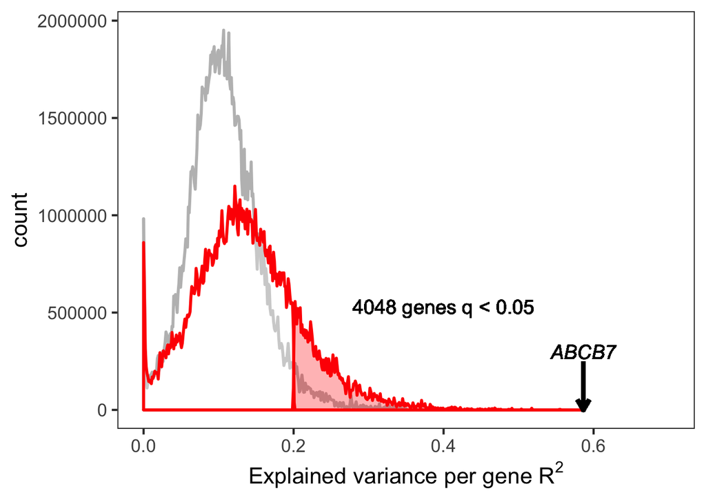

```r
ggplot(genetics) +
  geom_density(aes(Random,stat(count)),col="grey",adjust=0.01,size=1)+
  geom_density(aes(Observed,stat(count),fill=V3),col="red",adjust=0.01,size=1,alpha=0.3)+
  geom_text(aes(r+0.2,530000),label= paste(sum(Rgenetics > r), "genes q < 0.05"),size =5,)+
  geom_segment(aes(x=Rgenetics["22"], xend=Rgenetics["22"], y=250000, yend=1), size = 1.5,arrow = arrow(length = unit(0.3, "cm")))+
  geom_text(aes(Rgenetics["22"],300000),label= "ABCB7",size =5,fontface = "italic")+
  scale_fill_manual(values=c("white","red"))+
  labs(x=expression(paste("Explained variance per gene ", R^2)))+
  theme_bw(base_size=16)+
  theme(panel.grid=element_blank(),legend.position="none")+
  coord_cartesian(xlim=c(0,0.7))
```

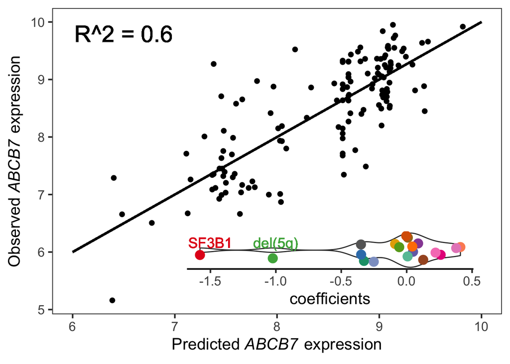

```r
expr <- data.frame(Predict=glmPrediction["22",],Overseved=geneExpr["22",rownames(design)])
vio_data <- as.data.frame(glm$coefficients["22",-1])
colnames(vio_data) <- "coefficients"
vio_data$color <- rownames(vio_data)

p1 <- ggplot(expr,aes(Predict,Overseved))+
  geom_point(size=2)+
  geom_segment(aes(x=6,xend=10,y=6, yend=10), size = 1)+
  labs(x=expression(paste("Predicted ",italic("ABCB7"), " expression")),y=expression(paste("Observed ",italic("ABCB7"), " expression")))+
  geom_text(aes(6.5,9.8,label= "R^2 = 0.6"),size=8)+
  theme_bw(base_size=16)+
  theme(panel.grid=element_blank(),legend.position="none")
  vio_data$color <- rownames(vio_data)

p2 <- ggplot(vio_data,aes(x=1,y=coefficients))+
  geom_violin(bw=0.1)+
  geom_jitter(aes(color=color),size=4)+
  geom_text(aes(1.2,-1.5),label= "SF3B1",size=5,col=colMutations["SF3B1"])+
  geom_text(aes(1.2,-1),label= "del(5q)",size=5,col=colMutations["del(5q)"])+
  coord_flip()+
  scale_color_manual(values=colMutations)+
  theme_classic(base_size=16)+
  theme(panel.grid=element_blank(),legend.position="none",
  axis.title.y=element_blank(),
  axis.text.y=element_blank(),
  axis.ticks.y=element_blank(),
  axis.line.y=element_blank())

#组图
library(cowplot)
p1+
  annotation_custom(ggplotGrob(p2),
  xmin=7,ymin=4.9,xmax=10,ymax=6.5)
```